# Midterm

Lin Wang

10/7/2020

## Introduction

### 1. Dataset

The datasets I used are:

California daily covid data from https://covidtracking.com/data/download

Covid data per US counties by NYT https://raw.githubusercontent.com/nytimes/covid-19-data/master/us-counties.csv

Both datasets include daily covid data such as cases, deaths, new cases, etc. California data starts from 03/04/2020, and county data starts from 01/21/2020.

### 2. Formulated question

I am going to look at California covid cases and trends. The main questions for this project are:

1. Which day has the most number of new cases and new deaths?
2. What is the trend of daily new cases?
3. What is the difference of covid trend between 2nd quarter and 3th quarter?
4. Which county has the most number of cases and deaths?

## Methods

### 1. Read in the data, EDA

- I choose data.table:: to download and read in large dataset, in order to keep latest covid history, I use download.file() and fread() to get updated daily data from the website.
- First I follow the EDA checklist to check dimensions, headers, footers, variable names and variable types. CA history data has 43 columns and 220 rows with IDate, int, char, logi variables, the first observation was on 03/04/2020. While county data has 6 columns and 612238 rows with IDate, chr, int variables(10/9), the first observation was on 01/21/2020.

```r
# Getting CA covid history data
download.file("https://covidtracking.com/data/download/california-history.csv", destfile = "california-history.csv")
dat <- fread("california-history.csv")

# Getting covid data per county in CA
download.file("https://raw.githubusercontent.com/nytimes/covid-19-data/master/us-counties.csv", destfile = "us-counties.csv", method="libcurl", timeout = 60)
counties <- fread("us-counties.csv")
```

### 2. Create new column, rename the key variables, convert variable type, check any missing values

- Next, datasets are filtered and selected using data.table:: and dplyr::. I list needed variables and rename some of them, and create a quarter variable in CA history data by selecting data from 04/01/2020 - 09/30/2020. And I filter county data where state equals to CA. I also convert type of the date variable for further use. As for missing value, I keep some NA’s in death and new cases columns because it would not affect our analysis.
- Now I get two datasets named as covid_ca and counties, I’ll use summary(), count(), table() to explore variable features and summary statistics.

```r
# selecting columns we need
dat <- dat[, .(date, state, death, deathIncrease, hospitalizedCurrently, positive, positiveIncrease, totalTestResults)] %>%
  rename(hospitalized = hospitalizedCurrently, newcases = positiveIncrease, cases = positive, tests = totalTestResults)

dat$date <- as.Date(dat$date)

# Creating Quarter variable
dat[date>="2020-04-01" & date<="2020-06-30", Quarter := "Q1"]
dat[date>="2020-07-01" & date<="2020-09-30", Quarter := "Q2"]

covid_ca <- dat[date>="2020-04-01" & date<="2020-09-30"][order(date, decreasing = FALSE)]

# Filtering CA data
counties <- counties %>%
  filter(state == "California")

counties$date <- as.Date(counties$date)
```

### 3. Data visualization

- The tools I use to visualized data mainly are ggplot() with multiple types of plot, usmap:: to present state map, kable() to make well-organized tables.

## Preliminary Results

### 1. Overview of covid cases, deaths, hospitalized cases, new cases in CA

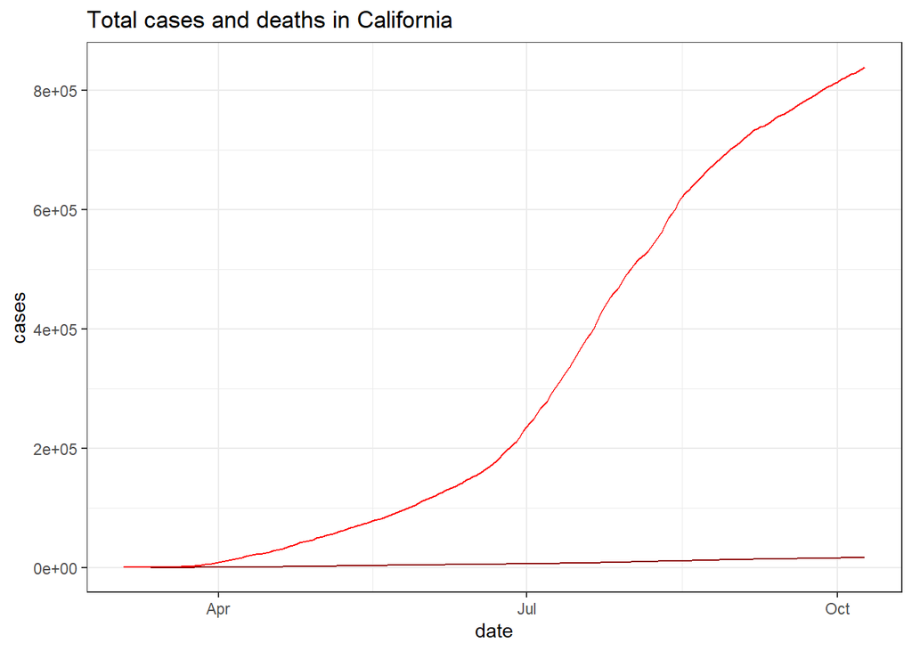

```r
ggplot(dat)+
  geom_line(mapping = aes(x = date, y = cases), col="red", na.rm = TRUE)+
  geom_line(mapping = aes(x = date, y = death), col = "darkred", na.rm = TRUE)+
  ggtitle("Total cases and deaths in California")+
  theme_bw()
```

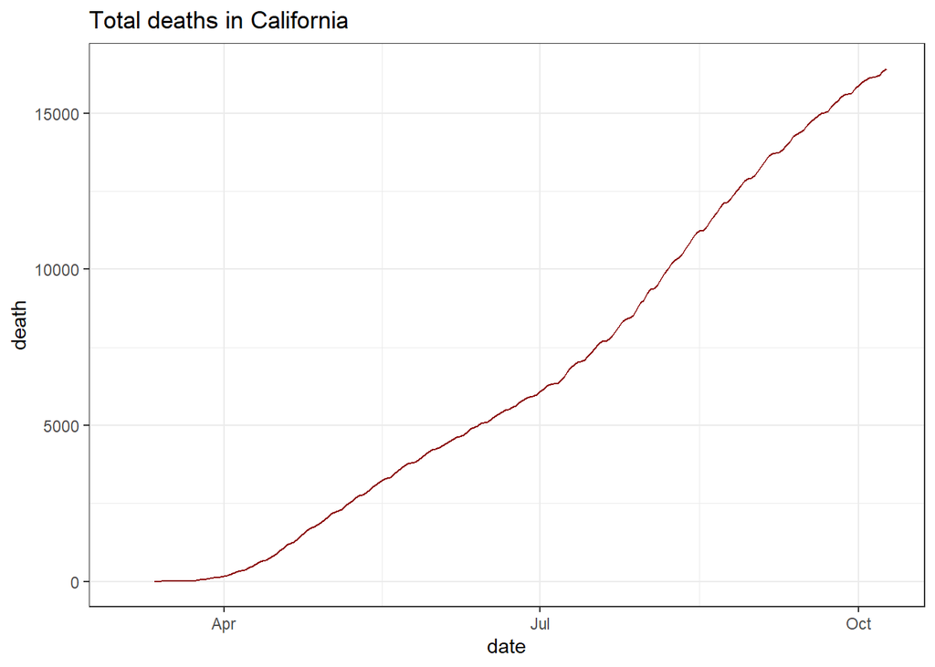

```r
ggplot(dat)+
  geom_line(mapping = aes(x = date, y = death), col = "darkred", na.rm = TRUE)+
  ggtitle("Total deaths in California")+
  theme_bw()
```

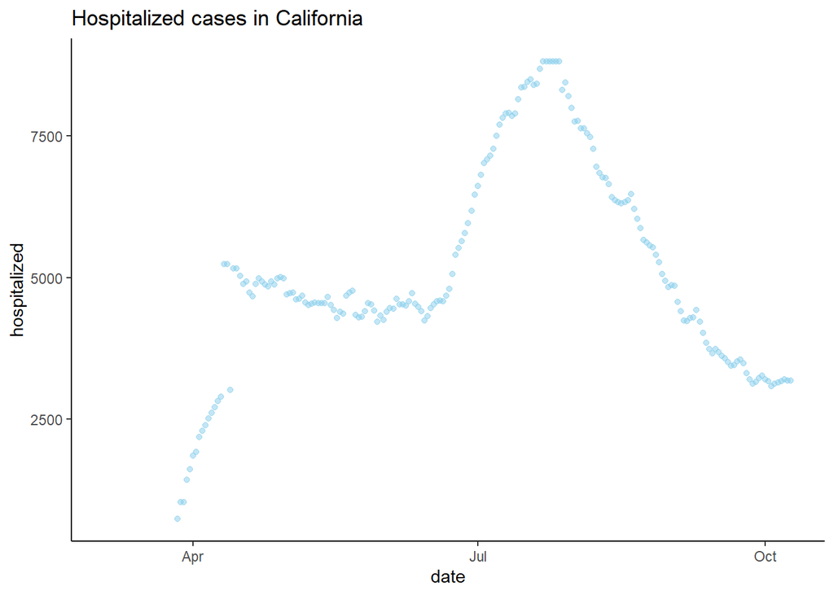

```r
ggplot(dat)+
  geom_point(mapping = aes(x = date, y = hospitalized), na.rm = TRUE, col="skyblue", alpha = 0.5)+
  ggtitle("Hospitalized cases in California")+
  theme_classic()
```

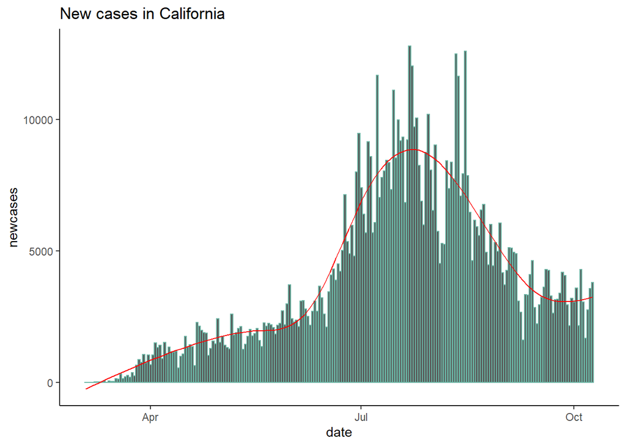

```r
ggplot(dat, mapping = aes(x = date))+
  geom_bar(aes(y = newcases), position = "stack", stat = "identity", col="#69b3a2", show.legend = TRUE, na.rm = TRUE)+
  stat_smooth(aes(date, newcases), method = "gam", color = "red", size = 0.5, se = FALSE)+
  ggtitle("New cases in California")+
  theme_classic()
```

### 2. Covid trend by quarters and months

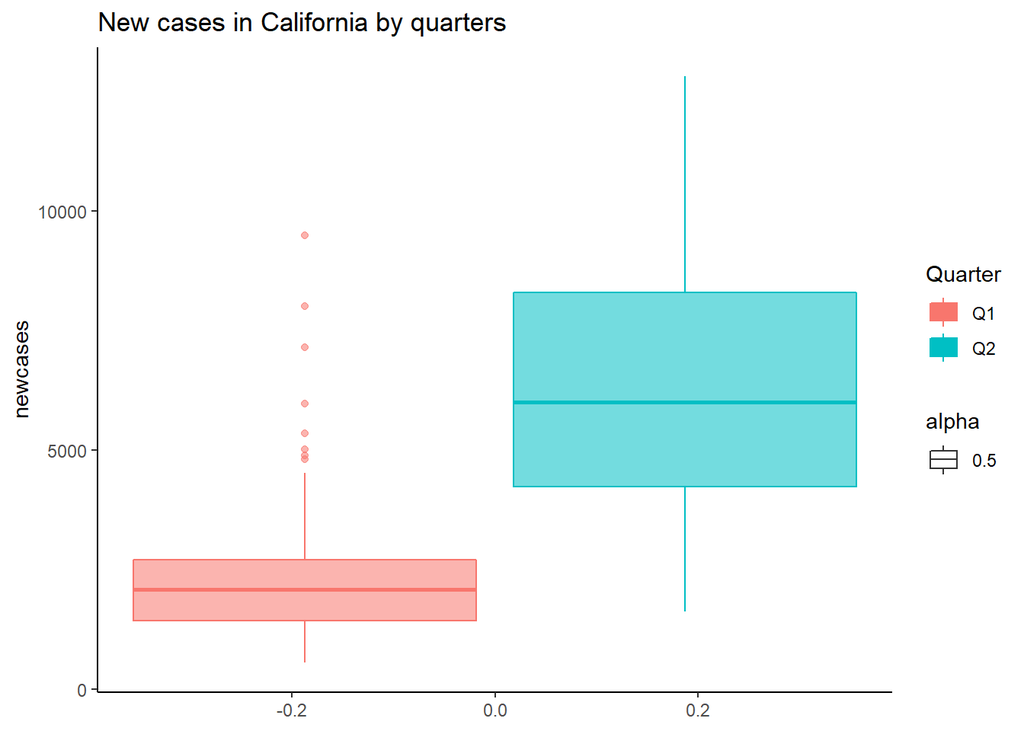

```r
# New cases by quarters
ggplot(covid_ca)+
  geom_boxplot(mapping = aes(group = Quarter, y = newcases, color = Quarter, fill = Quarter, alpha = 0.5))+
  ggtitle("New cases in California by quarters")+
  theme_classic()
```

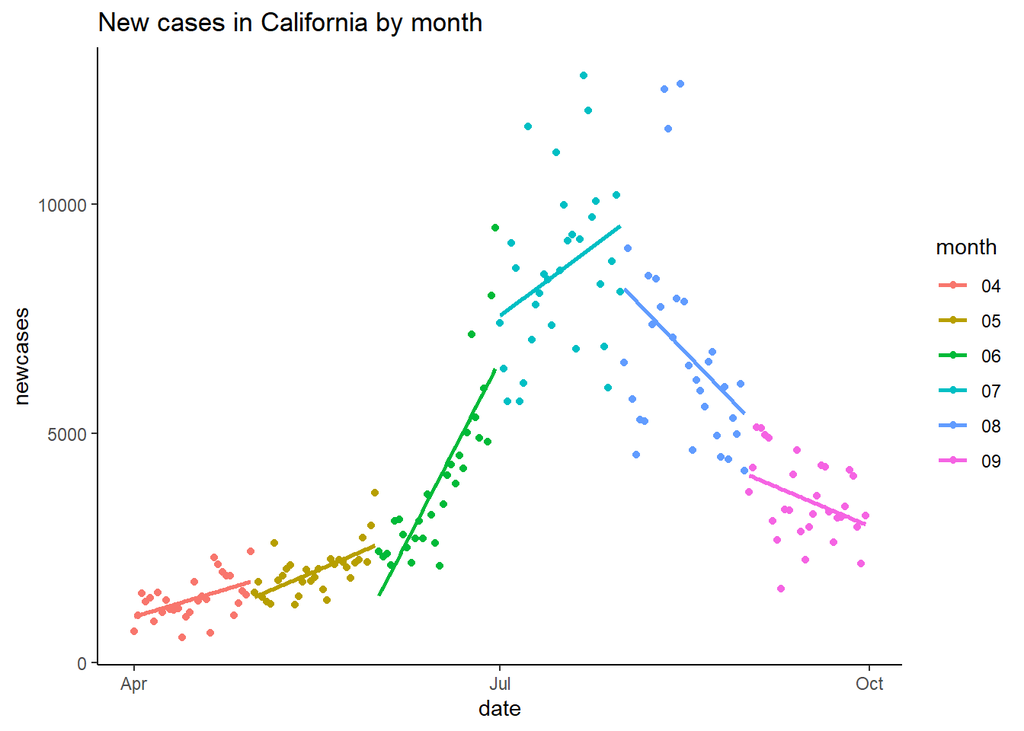

```r
# Take a look at different month
covid_ca1 = mutate(covid_ca, month=substr(covid_ca$date, 6, 7))
ggplot(covid_ca1)+
  geom_point(mapping = aes(x = date, y = newcases, color = month))+
  stat_smooth(aes(x = date, y = newcases, color = month), method = lm, se = FALSE)+
  ggtitle("New cases in California by month")+
  theme_classic()
```

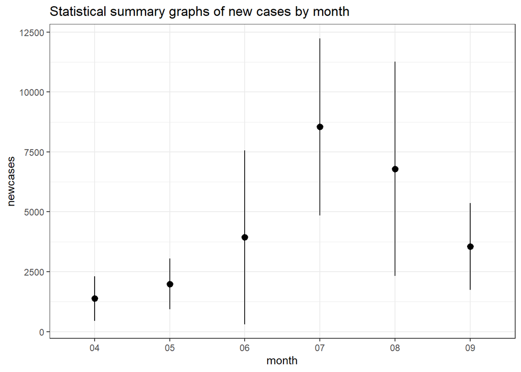

```r
# Statistical summary graph
ggplot(covid_ca1, mapping = aes(x = month, y = newcases))+
  stat_summary(fun.data = "mean_sdl")+
  ggtitle("Statistical summary graphs of new cases by month")+
  theme_bw()
```

- The 3th quarter(mean new_cases: 5000+) has more new cases than 2nd quarter(mean new_cases: 2500-).
- New cases is increasing drastically on June and get the top on July, it has a decreasing trend on the beginning of the August, which suggests precautions such as wearing mask and social distancing have impact on covid spread prevention. Overall, 3th quarter has more new cases.
- Statistical summary graph show same results with plots, July and August have most new cases.

### 3. County with top cases and deaths

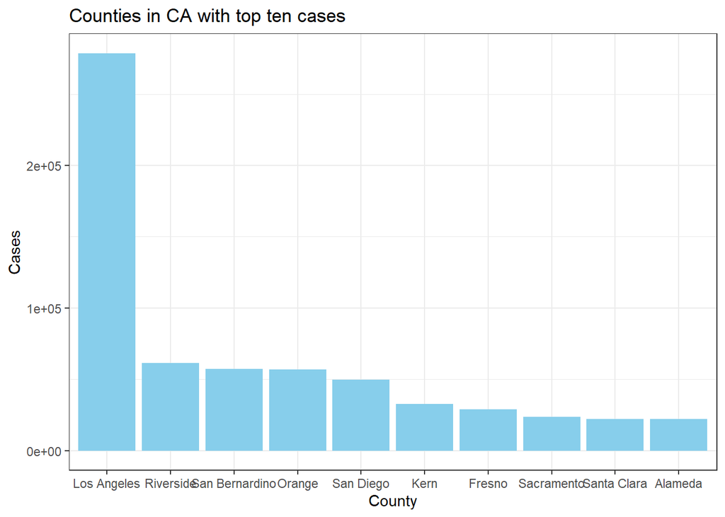

```r
# Getting the counties with top ten cases and deaths
top_cases <- counties %>%
  filter(date == max(date)) %>%
  select(county, cases) %>%
  arrange(desc(cases))
top_10_cases <- top_cases[1:10,]

top_deaths <- counties %>%
  filter(date == max(date)) %>%
  select(county, deaths) %>%
  arrange(desc(deaths))
top_10_deaths <- top_deaths[1:10,]

# plot
ggplot(top_10_cases, aes(x = reorder(county, -cases)))+
  geom_bar(aes(y = cases), position = "stack", stat = "identity", fill = "skyblue")+
  labs(title = "Counties in CA with top ten cases", x = "County", y = "Cases")+
  theme_bw()
```

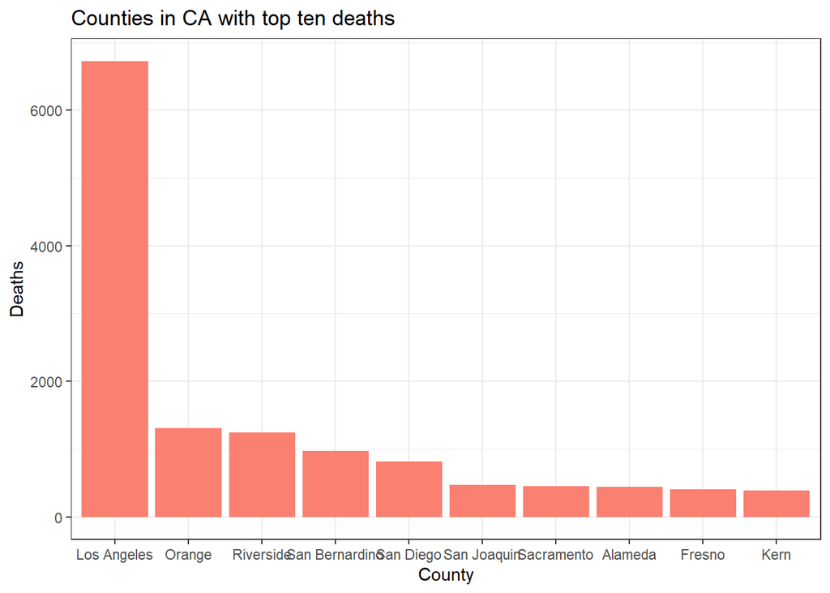

```r
ggplot(top_10_deaths, aes(x = reorder(county, -deaths)))+
  geom_bar(aes(y = deaths), position = "stack", stat = "identity", fill = "salmon")+
  labs(title = "Counties in CA with top ten deaths", x = "County", y = "Deaths")+
  theme_bw()
```

- Los Angeles is the county with the most number of cases and deaths.

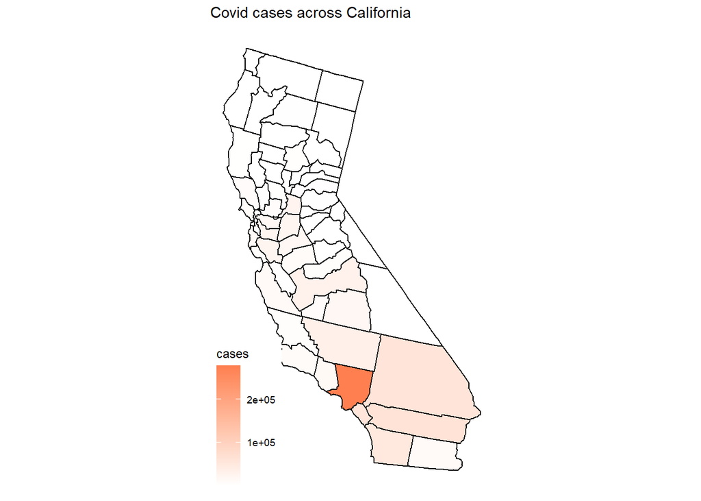

```r
# Plotting a state map
library(usmap)
map <- counties %>%
  filter(date == max(date)) %>%
  select(fips, cases, deaths)

plot_usmap("counties", data = map, values = "cases", include = "CA")+
  scale_fill_continuous(low = "white", high = "coral")+
  labs(title = "Covid cases across California", fill = "cases")
```

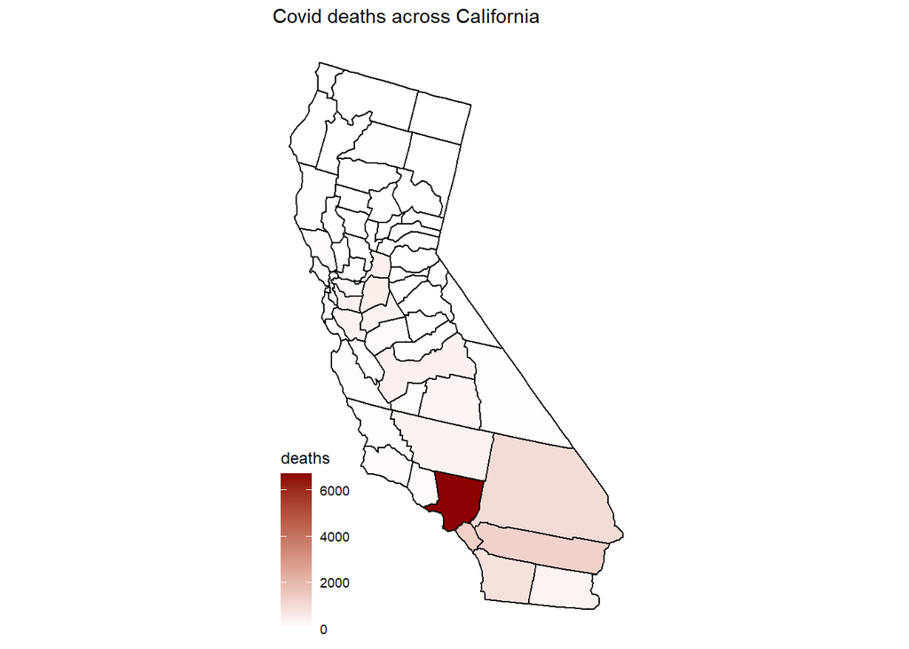

```r
plot_usmap("counties", data = map, values = "deaths", include = "CA")+
  scale_fill_continuous(low = "white", high = "darkred")+
  labs(title = "Covid deaths across California", fill = "deaths")
```

### 4. Take a look at Los Angeles County

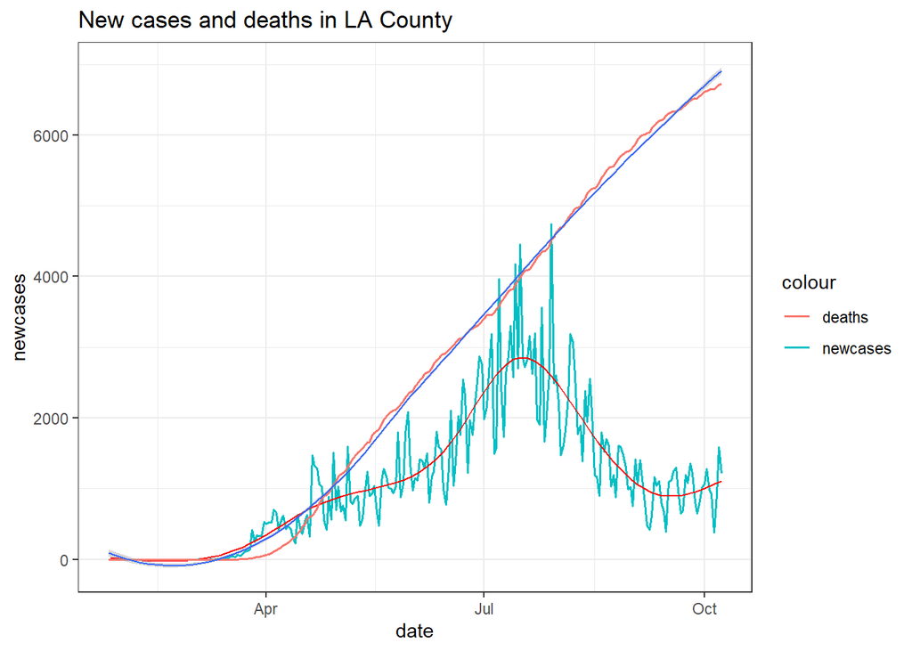

```r
lac <- counties %>%
  filter(county == "Los Angeles") %>%
  mutate(newcases = cases - lag(cases, 1)) %>%
  arrange(desc(cases))

ggplot(lac)+
  geom_line(mapping = aes(x = date, y = newcases, color = "newcases"), position = "stack", size = 0.7, na.rm = TRUE)+
  stat_smooth(aes(date, newcases), method = "gam", color = "red", size = 0.5, se = FALSE)+
  geom_line(mapping = aes(x = date, y = deaths, color = "deaths"), size = 0.7, na.rm = TRUE)+
  stat_smooth(aes(x = date, y = deaths), size = 0.5)+
  ggtitle("New cases and deaths in LA County")+
  theme_bw()
```

- The deaths line has a linear trend after April, the new cases line share a similar trend with state level.

### 5. Tables

```r
# Getting the day with the most number of new cases and new deaths
newcases <- dat %>%
  filter(newcases == max(newcases)) %>%
  select(date, newcases)

deaths <- dat %>%
  filter(deathIncrease == max(deathIncrease)) %>%
  select(date, deathIncrease)

knitr::kable(
  list(newcases, deaths),
  caption = "Day with the most number of new cases and deaths")
```

Day with the most number of new cases and deaths

| date | newcases |
| --- | --- |
| 2020-07-22 | 12807 |

| date | deathIncrease |
| --- | --- |
| 2020-08-01 | 219 |

```r
# Getting counties with top ten cases and deaths
knitr::kable(
  list(top_10_cases, top_10_deaths),
  caption = 'Counties with top ten cases and deaths.',
  booktabs = TRUE, valign = 't'
)
```

Counties with top ten cases and deaths.

| county | cases |
| --- | --- |
| Los Angeles | 278665 |
| Riverside | 61416 |
| San Bernardino | 57203 |
| Orange | 56800 |
| San Diego | 49529 |
| Kern | 32741 |
| Fresno | 29069 |
| Sacramento | 23522 |
| Santa Clara | 22154 |
| Alameda | 21959 |

| county | deaths |
| --- | --- |
| Los Angeles | 6726 |
| Orange | 1306 |
| Riverside | 1248 |
| San Bernardino | 974 |
| San Diego | 819 |
| San Joaquin | 473 |
| Sacramento | 447 |
| Alameda | 440 |
| Fresno | 406 |
| Kern | 387 |

```r
# Latest summary
dat[!is.na(cases), positiveprop := cases/tests]
latest <- dat[1, .(date, state, death, deathIncrease, hospitalized, cases, newcases, tests, positiveprop)]

knitr::kable(x = latest, caption = "Latest Covid Summary in CA")
```

Latest Covid Summary in CA

| date | state | death | deathIncrease | hospitalized | cases | newcases | tests | positiveprop |
| --- | --- | --- | --- | --- | --- | --- | --- | --- |
| 2020-10-09 | CA | 16428 | 67 | 3186 | 838606 | 3806 | 15736497 | 0.0532905 |

```r
lat_lac <- lac[1, .(date, county, cases, deaths, newcases)]
knitr::kable(x = lat_lac, caption = "Latest Covid Summary in LAC")
```

Latest Covid Summary in LAC

| date | county | cases | deaths | newcases |
| --- | --- | --- | --- | --- |
| 2020-10-08 | Los Angeles | 278665 | 6726 | 1220 |

## Conclusion

- 07/22/2020 is the day has the most new cases and 08/01/2020 has the most new deaths in CA.
- Daily new cases is increasing sharply on June, and has a peak at July and August, now it is decreasing gradually.
- The 3th quarter has more new cases than the 2nd quarter, and it has a mean of new cases at 5000+.
- Los Angeles county has the most number of cases and deaths which is 278665 and 6726 respectively.
- Covid pattern may be affected by people’s behavior and public health orders, that’s what I’m interested and may analyze it later.